# Predicting Churn for Bank Customers

Para realizar este trabajo se ocupo la base de datos disponibles en: https://www.kaggle.com/adammaus/predicting-churn-for-bank-customers

Este trabajo tiene dos misiones: 1)**Entender la situación del banco** de forma **grafica**, quienes son sus clientes, cuantos productos tienen. Y las variables que se correlacionan con la salida de un cliente del banco. 2)**Crear modelo de ML** que intente predecir que clientes se irán y cuáles se quedarán en un banco. De está forma el banco pueda tomar medidas preventivas con aquellos que se quieran retirar.

```python
# Librerías bases
import numpy as np
import pandas as pd

# Para visualizar
import matplotlib.pyplot as plt
%matplotlib inline
import seaborn as sns

# Para ML
#separar data entrenamiento y prueba
from sklearn.model_selection import train_test_split

#árbol de decisión
from sklearn import tree

#Random Forest
from sklearn.ensemble import RandomForestClassifier
from sklearn.datasets import make_classification

#Revisar ML
from sklearn.metrics import confusion_matrix
from sklearn.metrics import accuracy_score
from sklearn.metrics import auc
```

```python
from sklearn.tree import export_graphviz
from subprocess import call
```

Cargar archivo

```python
df = pd.read_csv('./Churn_Modelling.csv')
```

```python
df.head(4)
```

|  | RowNumber | CustomerId | Surname | CreditScore | Geography | Gender | Age | Tenure | Balance | NumOfProducts | HasCrCard | IsActiveMember | EstimatedSalary | Exited |
| --- | --- | --- | --- | --- | --- | --- | --- | --- | --- | --- | --- | --- | --- | --- |
| 0 | 1 | 15634602 | Hargrave | 619 | France | Female | 42 | 2 | 0.00 | 1 | 1 | 1 | 101348.88 | 1 |
| 1 | 2 | 15647311 | Hill | 608 | Spain | Female | 41 | 1 | 83807.86 | 1 | 0 | 1 | 112542.58 | 0 |
| 2 | 3 | 15619304 | Onio | 502 | France | Female | 42 | 8 | 159660.80 | 3 | 1 | 0 | 113931.57 | 1 |
| 3 | 4 | 15701354 | Boni | 699 | France | Female | 39 | 1 | 0.00 | 2 | 0 | 0 | 93826.63 | 0 |

Importante: Notemos que la base de datos **no contiene ningun dato de fecha**. Que indique **cuando** el cliente se **retiro** (en caso de verlo hecho) o cuando **tomo un determinado producto** (para ver si se retiran después de tomar un determinado producto).

```python
df[df.isnull().any(axis=1)]
```

|  | RowNumber | CustomerId | Surname | CreditScore | Geography | Gender | Age | Tenure | Balance | NumOfProducts | HasCrCard | IsActiveMember | EstimatedSalary | Exited |
| --- | --- | --- | --- | --- | --- | --- | --- | --- | --- | --- | --- | --- | --- | --- |

No existen valores nulos en está base de datos!

```python
df.nunique()
```

```
RowNumber          10000
CustomerId         10000
Surname             2932
CreditScore          460
Geography              3
Gender                 2
Age                   70
Tenure                11
Balance             6382
NumOfProducts          4
HasCrCard              2
IsActiveMember         2
EstimatedSalary     9999
Exited                 2
dtype: int64
```

```python
del df['RowNumber']
del df['CustomerId']
del df['Surname']
```

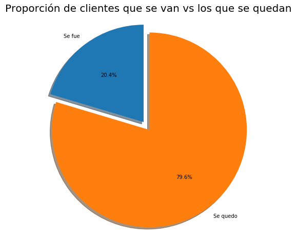

```python
labels = 'Se fue', 'Se quedo'
sizes = [df.Exited[df['Exited']==1].count(), df.Exited[df['Exited']==0].count()]
explode = (0, 0.1)
fig1, ax1 = plt.subplots(figsize=(10, 8))
ax1.pie(sizes, explode=explode, labels=labels, autopct='%1.1f%%',
        shadow=True, startangle=90)
ax1.axis('equal')
plt.title("Proporción de clientes que se van vs los que se quedan", size = 20)
plt.show()
```

Notemos que **se van un 20.4% de los clientes**, es decir un quinto de la empresa. Por lo tanto no es necesario hacer técnicas de downsamplig y upweighting ya que las clases están relativamente balanceadas.

Veamos las correlaciones entre variables para ver como se relacionan entre ellas. Y así saber que nos gustaría gráficar para entender mejor el problema que nos enfrentamos.

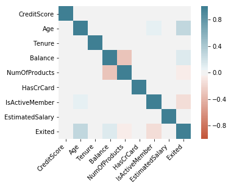

```python
corr = df.corr()
ax = sns.heatmap(
    corr,
    vmin=-1, vmax=1, center=0,
    cmap=sns.diverging_palette(20, 220, n=200),
    square=True
)
ax.set_xticklabels(
    ax.get_xticklabels(),
    rotation=45,
    horizontalalignment='right'
);
```

**Analisis Exploratorio:** Exited (Si el cliente se va es 1) está **negativamente correlacionado** si el cliente es un **miembro activo** o no (esto es relativamente obvio) y con el **número de productos** que el cliente tiene.

Dicho de otra forma, si el **cliente es un miembro** es 1 por lo tanto es **más probable**que **se quede (exiter=0)**. Y si el **cliente tiene más productos**, es más probable el **cliente se quede** (exited=0). Notemos la lectura de esta variable. **Son correlacionales y no causales**. (puede leer aquì la diferencia https://aprendeingenieria.com/correlacion-≠-causalidad/) Es decir, hay por lo menos dos escenarios. CLientes con más productos no quieran salirse del banco (por flojera a tener que, por ejemplo, sacar todos los productos de nuevo). O bien clientes que les gusta mucho el banco sacan hartos productos y por eso no se van.

Noté que a su vez estás variables están relacionadas positivamente con si el cliente se va (exited=1.) Es decir **clientes con más edad tienden a irse** como a su vez **clientes con un mejor balance**.

Para entender un poco más la situación. Se hará un analisis visual de las variables para facilitar su entendimiento.

Se debe gráficar (entre paréntesis va el tipo de variable): Edad (ordinal), balance(quantitativa), usuarios activos(categórica), número de productos(ordinal). Adicionalmente geografía y sexo deben graficarse para entender que tipo de clientes se tienen.

Nota: Estas variables que se mueven en conjunto sería bueno analizarlas con estudios y preguntas al consumidor para entender porque se dan estos patrones.

# Análisis preliminar (Visual)

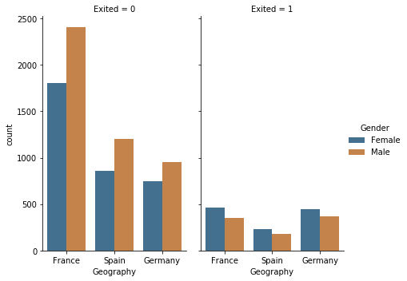

```python
a=sns.catplot(x="Geography", hue="Gender", col="Exited",
                data=df, saturation=.5,
                kind="count", ci=None, aspect=.6)
```

Sería conveniente tener un **benchmark**, para ver si es común a todos los bancos que los hombres se queden conformes con sus productos en un banco o no. Y si es común que en Francia que las personas se queden con su banco.

## ¿Quién es el cliente?

Analicemos el tipo de cliente y su comportamiento con los productos del banco.

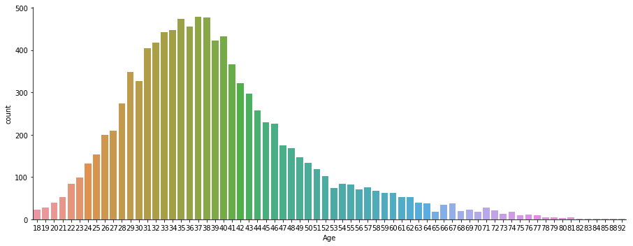

```python
b = sns.catplot(x="Age",
              data=df, kind="count",
               height=5, aspect=2.5);
```

Entonces lo que se sabe hasta ahora es que probablemente la mayoría de los clientes de la empresa son de francia, hombres con una edad que va desde los 29 hasta los 44.

Revisemos ahora si esto es cierto:

```python
Male=df["Gender"]=="Male"
#df[Male].count() #un poco más de la mitad (Pero son los hombres lo que se quedan en general)
```

```python
France=df["Geography"]=="France"
#df[France].count() #de 3 paises francia tiene la mitad
```

```python
#df.dtypes Importante Age es un integer (lo cual està bien para los análisis)
```

```python
Edad1=df["Age"]<45
Edad2=df["Age"]>28
Edad= Edad1 & Edad1
#df[Edad].count() casi 8000 de los datos cumplen este requisito (80%)
```

```python
filtro=France & Edad
#df[filtro].count()
#hay 3934 datos es casi un 40% de los datos corresponden a personas
#entre 28-45 de Francia. (La edad va desde 18 hasta los 92 y hay 3 países)
# es importante resaltar esto ya que el modelo será entrenado con estos datos pero la base
# está muy cargada a estos valores. Por ejemplo si aumenta el número de clientes jovenes
# (o el número de clientes en otro país) se tendrá que actualizar el
# modelo porque puede correr el riesgo de no predecir correctamente.
```

## ¿Qué hace?

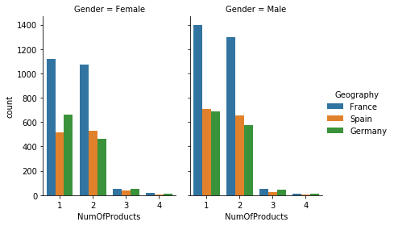

```python
c = sns.catplot(x="NumOfProducts", hue="Geography", col="Gender",
                 data=df, kind="count",
              height=4, aspect=.7);
```

Los **hombres en general** (independiente del país) tienen **menos productos**. Este comportamiento también se da en las mujeres **salvo en españa que suelen tener 2 productos en vez de 1** (es muy bajo mayor).

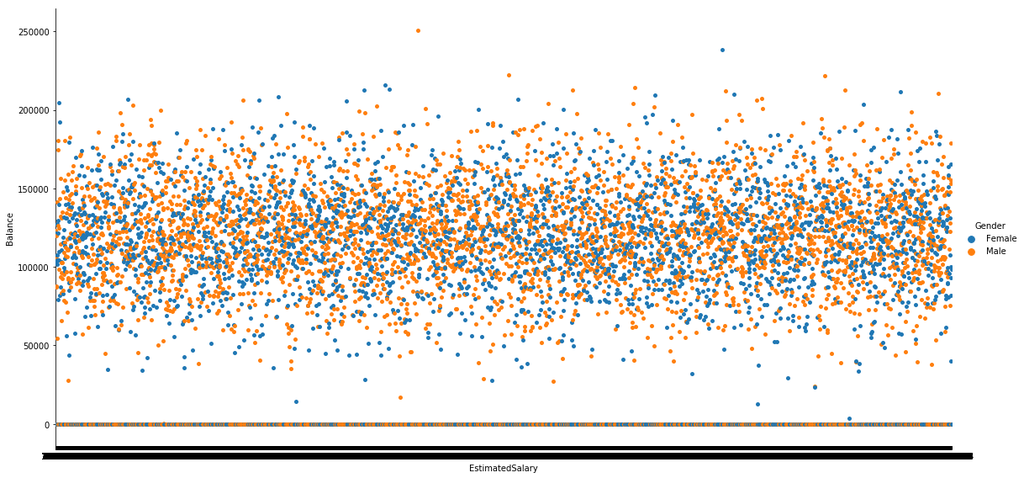

```python
d = sns.catplot(x="EstimatedSalary", y="Balance", hue="Gender", data=df,
                 height=8, aspect=2)
# se puede agregar col= Geography para ver si los comportamiento del balance dependen del país,
# Pero se dejará de lado en esta oportunidad aquí, pero queda propuesta la idea ;)
```

Análisis: Este gráfico que parecia interesante de hacerse, no muestra un patrón evidente de si los hombres o mujeres tienen un mejor balance dado el sueldo.

```python
#df.EstimatedSalary.describe()
#sueldo mínimo 11.58 y max 199992.48 es decir pese a la gran varianza de este el balance no se mueve acorde en alguna direccion en funcion a este
#o dicho de otra forma la varianza del balance no queda explicada por la del sueldo estimado.
```

Se pueden crear nuevas variables a partir de las antiguas. Por ejemplo un ratio del balance vs sueldo estimado. Sin embargo dado que no se sabe como se calculo este sueldo estimado (puede verse calculado usando el mismo balance más otras métricas) se calculará un modelo usando las variables iniciales, sin cambios. Si el modelo requiere mejorarse se podrá re-evaluar está alternativa.

# Feature Engineer

```python
gend=pd.get_dummies(df.Gender)
geo=pd.get_dummies(df.Geography)
obj=[df,gend,geo]
df=pd.concat(obj, axis=1)
```

```python
df.head(1)
```

|  | CreditScore | Geography | Gender | Age | Tenure | Balance | NumOfProducts | HasCrCard | IsActiveMember | EstimatedSalary | Exited | Female | Male | France | Germany | Spain |
| --- | --- | --- | --- | --- | --- | --- | --- | --- | --- | --- | --- | --- | --- | --- | --- | --- |
| 0 | 619 | France | Female | 42 | 2 | 0.0 | 1 | 1 | 1 | 101348.88 | 1 | 1 | 0 | 1 | 0 | 0 |

# ML en acción

Se usará primero un árbol de decisión y se gráficará. Esto es para entender de mejor manera los gatillantes a que un cliente se vaya del Banco. Luego se hará un Random Forest cómo ML propuesto para este problema.

```python
df.columns #ver columnas gender y el país deben cambiarse por dummies para poder operar con ellas
```

```
Index(['CreditScore', 'Geography', 'Gender', 'Age', 'Tenure', 'Balance',
       'NumOfProducts', 'HasCrCard', 'IsActiveMember', 'EstimatedSalary',
       'Exited', 'Female', 'Male', 'France', 'Germany', 'Spain'],
      dtype='object')
```

```python
labels=['CreditScore', 'Age', 'Tenure', 'Balance',
       'NumOfProducts', 'HasCrCard', 'IsActiveMember', 'EstimatedSalary',
        'Female', 'Male', 'France', 'Germany', 'Spain']
```

Crear variables de prueba y testeo

```python
X= df[labels]
y=df[['Exited']]
```

```python
X_train, X_test, y_train, y_test = train_test_split(X, y, test_size=0.33, random_state=2)
```

```python
churn_classifier = tree.DecisionTreeClassifier(max_leaf_nodes=8, random_state=0)
churn_classifier.fit(X_train, y_train)
```

```
DecisionTreeClassifier(class_weight=None, criterion='gini', max_depth=None,
            max_features=None, max_leaf_nodes=8, min_impurity_decrease=0.0,
            min_impurity_split=None, min_samples_leaf=1,
            min_samples_split=2, min_weight_fraction_leaf=0.0,
            presort=False, random_state=0, splitter='best')
```

```python
tree.export_graphviz(churn_classifier)
```

[output not shown]

```python
export_graphviz(churn_classifier, 'tree.dot', rounded = True,
                feature_names = ['CreditScore', 'Age', 'Tenure', 'Balance',
       'NumOfProducts', 'HasCrCard', 'IsActiveMember', 'EstimatedSalary', 'Female', 'Male', 'France', 'Germany', 'Spain'],
                class_names = ['Se quedo', 'se fue'], filled = True)
```

```python
# Convert to png
call(['dot', '-Tpng', 'tree.dot', '-o', 'tree.png', '-Gdpi=400']);
```

```python
from IPython.display import Image
```

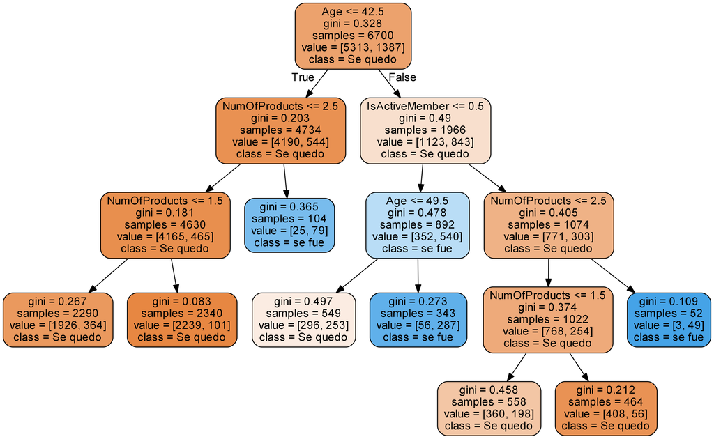

```python
Image('tree.png')
```

```python
labelsImportantes= zip(labels,churn_classifier.feature_importances_)
print(tuple(labelsImportantes))
```

```
(('CreditScore', 0.0), ('Age', 0.5291104992618196), ('Tenure', 0.0), ('Balance', 0.0), ('NumOfProducts', 0.3092515255087582), ('HasCrCard', 0.0), ('IsActiveMember', 0.1616379752294221), ('EstimatedSalary', 0.0), ('Female', 0.0), ('Male', 0.0), ('France', 0.0), ('Germany', 0.0), ('Spain', 0.0))
```

Los atributos más importantes para ver si un cliente se va o no son: la **edad**, el **número de productos** y si es un **miembro**. Para entender un poco la lógica e interacción entre variables conviene revisar con calma el árbol de decisión.

```python
predicciones = churn_classifier.predict(X_test)
accuracy_score(y_true = y_test, y_pred = predicciones)
```

```
0.8390909090909091
```

el modelo predice con un 84% si el cliente se va o no. Sin embargo, es mejor saber como está el modelo respecto a la matriz de confusión, para saber cuantos falsos negativos tiene (ya que probablemente estos sean los más costosos). Los falsos negativos son los que el modelo predice incorrectamente que se quedarán, pero en verdad se retiran del banco.

```python
confusion_matrix(y_true = y_test, y_pred = predicciones, labels=[0,1])
```

```
array([[2602,   48],
       [ 483,  167]], dtype=int64)
```

```python
#se_Van=y_test[y_test['Exited']==1].count()
#se_Van
```

```python
#quedan=y_test[y_test['Exited']==0].count()
#quedan
```

Notemos que el modelo se equivoca con 483 clientes que se van (prediciendo que se quedarían), este valor lo vamos a tratar de corregir usando random forest. (Los errores totales del modelo son 483+48=531)

```python
model = RandomForestClassifier(n_estimators=100,
                               random_state=200,
                               max_features = 'sqrt',
                               n_jobs=-1, verbose = 1)


model.fit(X_train, y_train)
```

```
RandomForestClassifier(bootstrap=True, class_weight=None, criterion='gini',
            max_depth=None, max_features='sqrt', max_leaf_nodes=None,
            min_impurity_decrease=0.0, min_impurity_split=None,
            min_samples_leaf=1, min_samples_split=2,
            min_weight_fraction_leaf=0.0, n_estimators=100, n_jobs=-1,
            oob_score=False, random_state=200, verbose=1, warm_start=False)
```

```python
predicciones2=model.predict(X_test)
accuracy_score(y_true = y_test, y_pred = predicciones2)
```

```
[Parallel(n_jobs=4)]: Using backend ThreadingBackend with 4 concurrent workers.
[Parallel(n_jobs=4)]: Done  42 tasks      | elapsed:    0.0s
[Parallel(n_jobs=4)]: Done 100 out of 100 | elapsed:    0.0s finished
```

```
0.8569696969696969
```

# ¿Dónde nuestro modelo más se equivoca?

```python
confusion_matrix(y_true = y_test, y_pred = predicciones2, labels=[0,1])
```

```
array([[2550,  100],
       [ 372,  278]], dtype=int64)
```

Notemos que random forest tiene mejor nivel de predicción. Adicionalmente el error más costoso (incorrectamente clasificar a los que se van como que se quedan) disminuyo notablemente a 372 (errores totales son: 472). El modelo seguirá mejorando a medida que se tengan más datos. Revisemos un poco los errores (país y edad)

```python
predicciones3=pd.DataFrame(data=predicciones2) # necesitamos trabajar con dataframes
```

```python
predicciones3.iloc[8,0]
```

```
1
```

```python
errores=[]
j=0
rowss=[]
n_errores=0
for index, row in y_test.iterrows():
    if y_test.iloc[j,0]!= predicciones3.iloc[j,0]:
           # print(index)
            #print(j)
            errores.append(index)
            rowss.append(j)
            j=j+1
            n_errores=n_errores+1 #este es el total de errores debe dar 472 como la matriz de confusión
    else:
        j=j+1
```

```python
# n_errores #resultado correcto 472
```

```python
mistake=X_test.iloc[rowss]
```

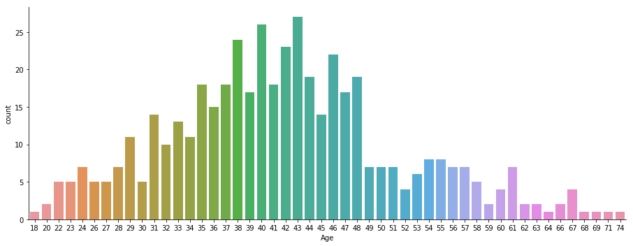

```python
b = sns.catplot(x="Age",
              data=mistake, kind="count",
               height=5, aspect=2.5);
```

Note como distribuye el error en este gráfico. Claramente el % de error (equivocadas/total estimadas) es mayor en segmento etario donde nuestro modelo tiene menos datos. (aquí no se calcularán porcentajes de error, ya que el foco es llegar a un buen modelo de ML y análizar visualmente el contenido para mejorar su entendendimiento).

```python
# revisemos que los errores que tenemos en mistake sean efectivamente los errores:
#mistake.head(5) se revisa esto con predicciones3 e y_test
```

[output not shown]